# pjt_bank_marketing

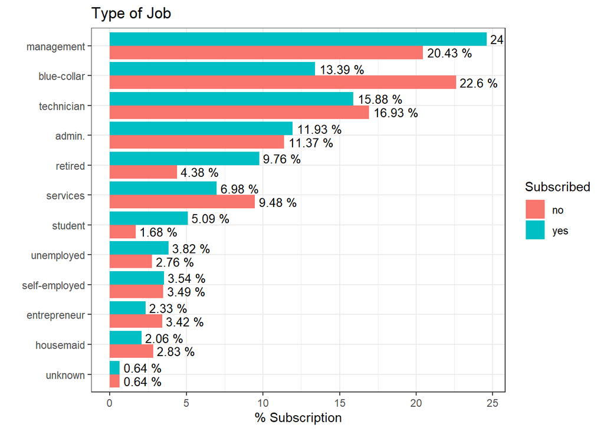

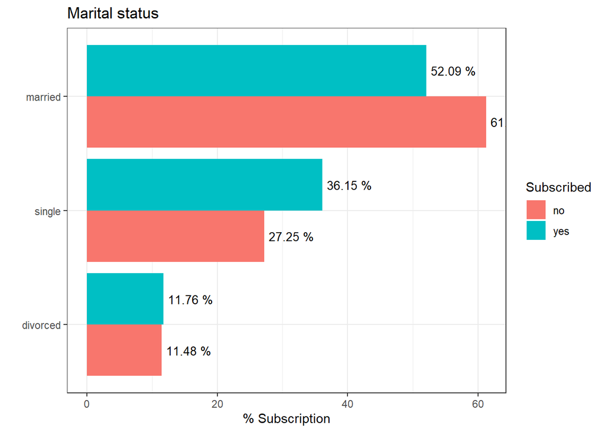

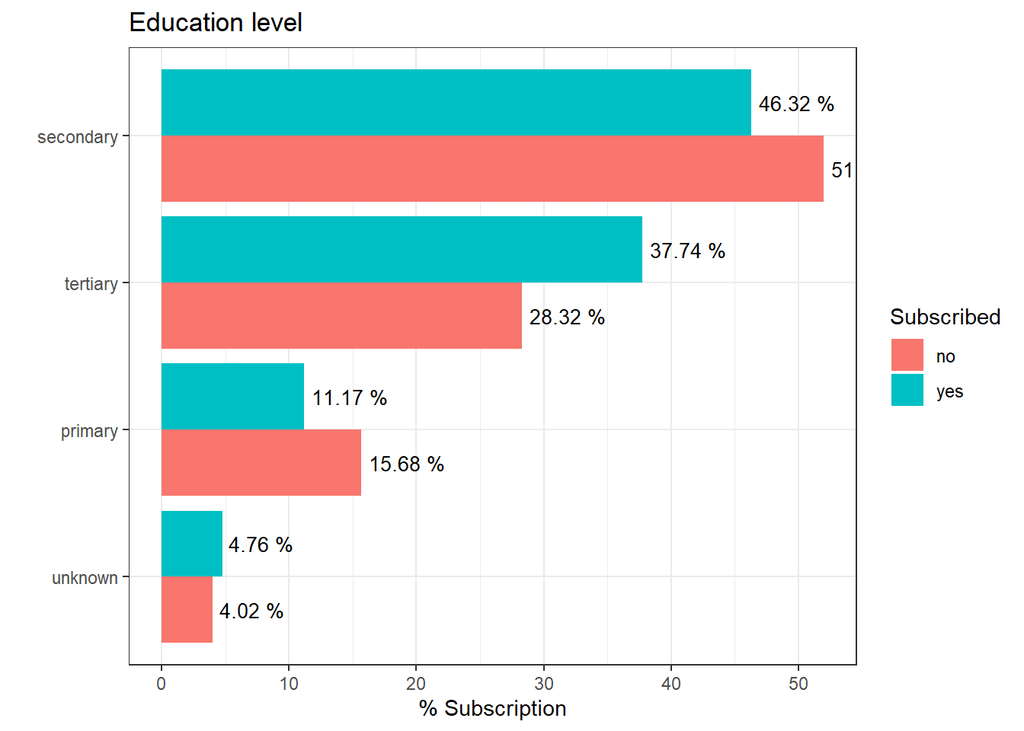

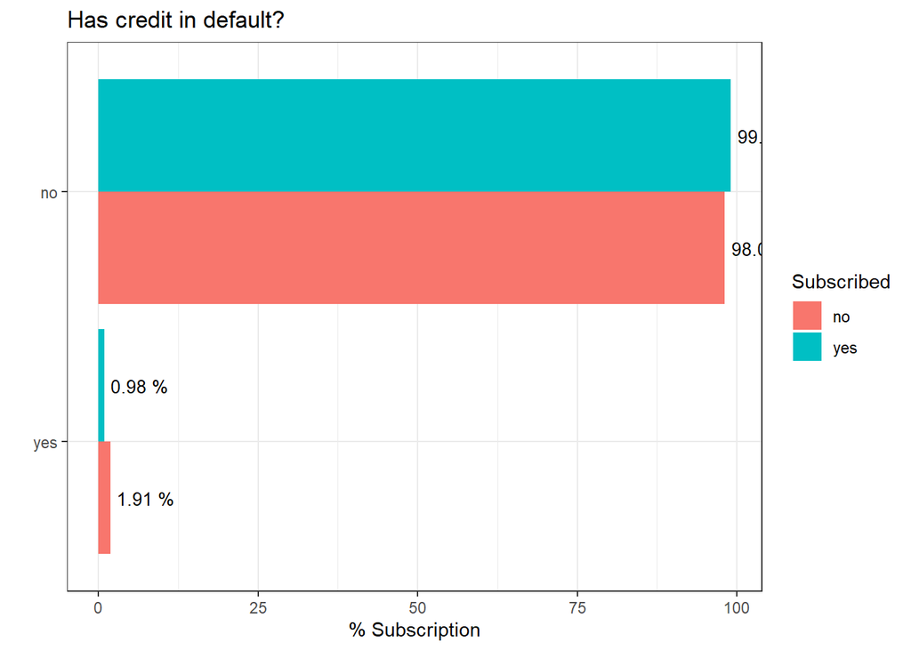

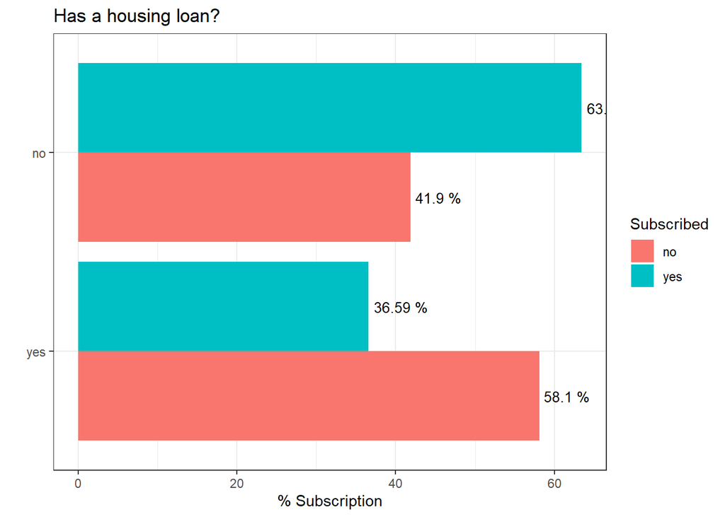

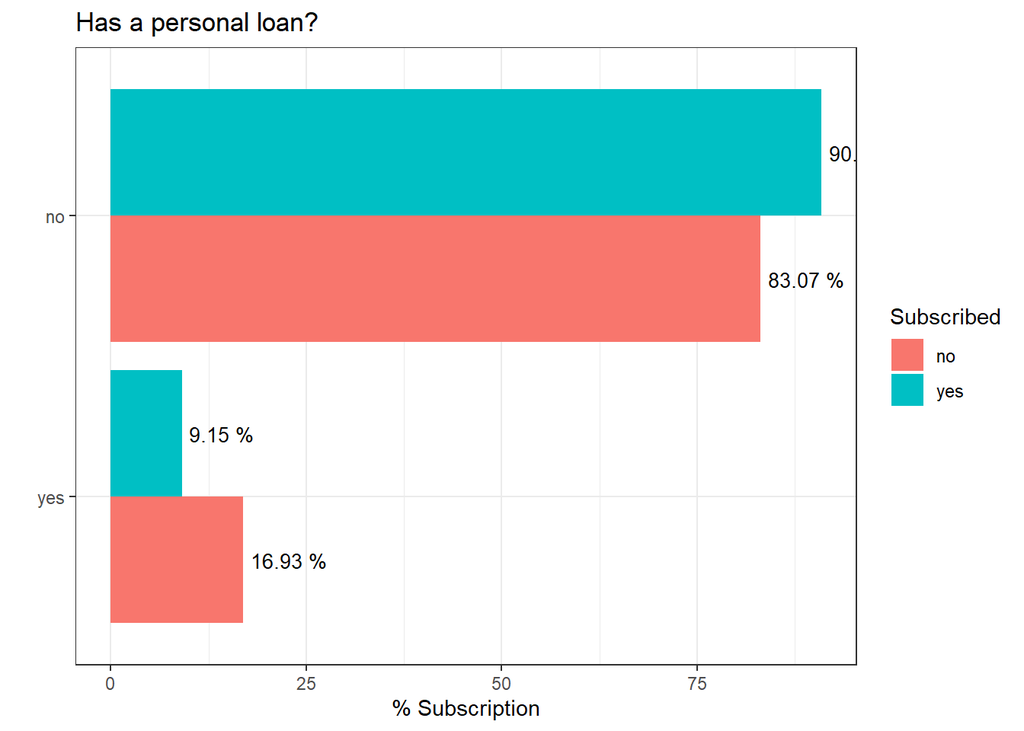

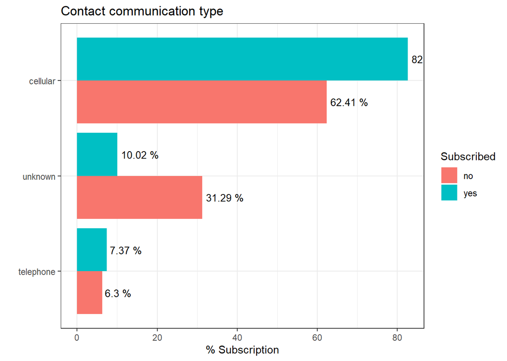

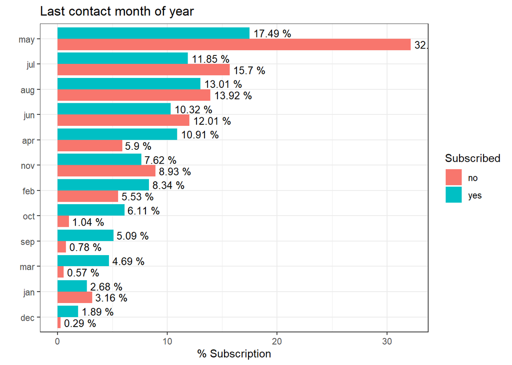

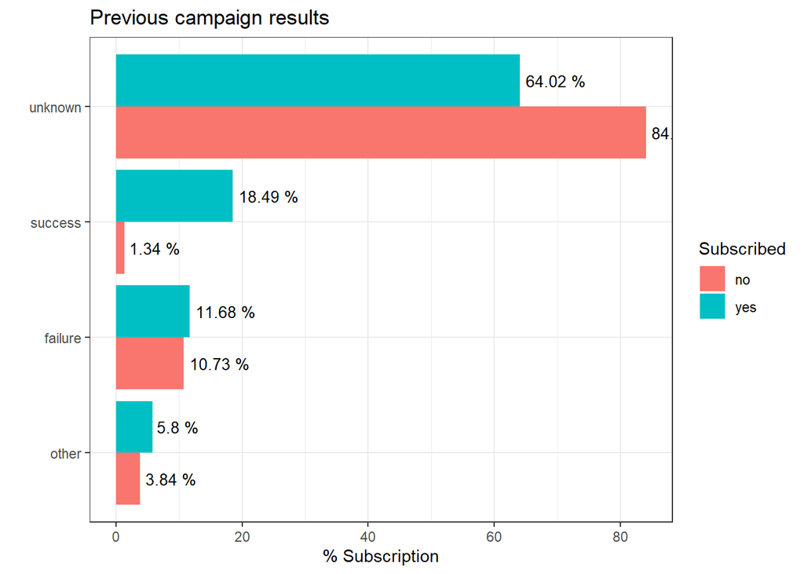

```r
desc <- c("Type of Job", "Marital status", "Education level", "Has credit in default?", "Has a housing loan?",
          "Has a personal loan?", "Contact communication type", "Last contact month of year", "Previous campaign results")
colnm2 <- colnames(bank[sapply(bank, is.factor)] %>% select(-y))

for (i in 1:length(colnm2)) {
  print(bank %>%
    group_by(y,!!sym(colnm2[i])) %>% summarize(cnt=n(), .groups="drop") %>%
    group_by(y) %>% mutate(Percent = cnt/sum(cnt)*100) %>%
    ggplot(aes(x = reorder(!!sym(colnm2[i]), Percent, FUN=max), y = Percent, fill = y)) +
    geom_bar(stat = "identity", position = "dodge") +
    geom_text(aes(label=paste(round(Percent,2),"%")), position = position_dodge(width = 0.9), hjust = -0.1, size=3.5) +
    labs(title = desc[i],
         x = "",
         y = "% Subscription",
         fill = "Subscribed") +
    coord_flip() +
    theme_bw())
}
```

# 3. Customer Segmentation — K means

```r
# Scale only numeric variables
numeric_vars <- bank %>% select(where(is.numeric))
scaled_numeric_vars <- as.data.frame(scale(numeric_vars))

# Combine the scaled numeric variables with the categorical variables
categorical_vars <- bank %>% select(where(is.factor))
scaled_bank <- cbind(scaled_numeric_vars, categorical_vars)

# Convert only categorical variables to dummy variables
scaled_bank_dummies <- scaled_bank %>%
  mutate_if(is.factor, as.character) %>%
  mutate_if(is.character, as.factor) %>%
  model.matrix(~ . -1, data = .) %>%
  as.data.table()
```

## Elbow Test

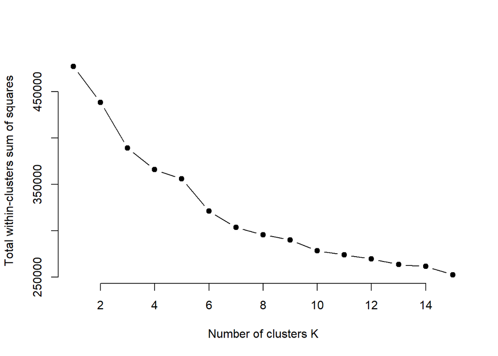

```r
# # Elbow Test
# set.seed(208) # For reproducibility
#
# # Register parallel backend
# cl <- makeCluster(detectCores() - 1) # Use one less core than available
# registerDoParallel(cl)
#
# # Sample a subset of the data
# sampled_data <- scaled_bank_dummies[sample(1:nrow(scaled_bank_dummies), size = 1000), ]
#
# # Run fviz_nbclust with parallel processing
# fviz_nbclust(sampled_data, kmeans, method = "wss", k.max = 10)
#
# # Stop the parallel backend
# stopCluster(cl)
# registerDoSEQ()

set.seed(208)

wss <- function(k) {
  kmeans(scaled_bank_dummies, k)$tot.withinss
}
k.values <- 1:15
wss.values <- sapply(k.values, wss)

plot(k.values, wss.values, type="b", pch = 19, frame = FALSE,
     xlab="Number of clusters K",
     ylab="Total within-clusters sum of squares")
```

**Based on the elbow plot shown, the optimal number of clusters to be 3.**

## K-Means Cluster Plot

```r
# Apply k-means clustering

# optimal
set.seed(208)
StrattonCluster_3k <- kmeans(scaled_bank_dummies, 3)
set.seed(208)
StrattonCluster_4k <- kmeans(scaled_bank_dummies, 4)
set.seed(208)
StrattonCluster_5k <- kmeans(scaled_bank_dummies, 5)
set.seed(208)
StrattonCluster_6k <- kmeans(scaled_bank_dummies, 6)
```

*I changed the x, y scaling to exclude the most skewed outliers.*

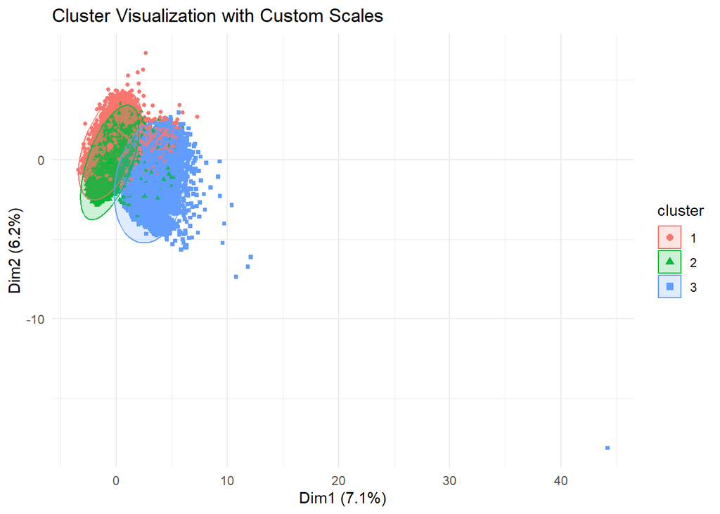

```r
set.seed(208)
# # Visualize the clusters k = 3
fviz_cluster(StrattonCluster_3k, data = scaled_bank_dummies,
              ellipse.type = "norm", geom = "point", pointsize = 1) +
   ggtitle("Cluster Visualization with Custom Scales") +
   theme_minimal()
```

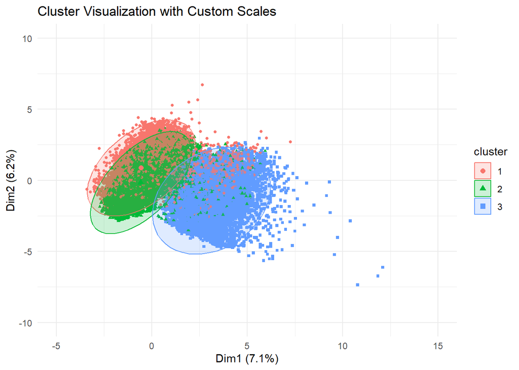

```r
# # Visualize the clusters k = 3 without outlier
 fviz_cluster(StrattonCluster_3k, data = scaled_bank_dummies,
              ellipse.type = "norm", geom = "point", pointsize = 1) +
   xlim(-5, 15) + # Adjust x-axis limits
   ylim(-10, 10) + # Adjust y-axis limits
   ggtitle("Cluster Visualization with Custom Scales") +
   theme_minimal()
```

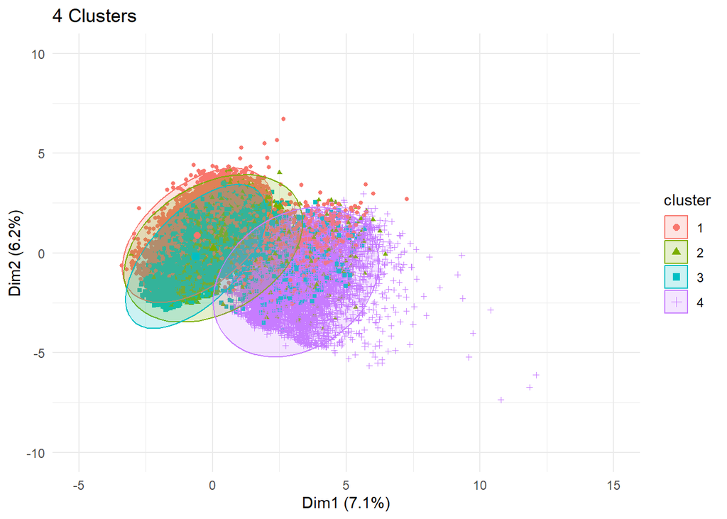

```r
set.seed(208)
# Visualize the clusters k = 4
Cluster4 <- fviz_cluster(StrattonCluster_4k, data = scaled_bank_dummies,
             ellipse.type = "norm", geom = "point", pointsize = 1) +
  xlim(-5, 15) + # Adjust x-axis limits
  ylim(-10, 10) + # Adjust y-axis limits
  ggtitle("4 Clusters") +
  theme_minimal()

set.seed(208)
# Visualize the clusters k = 5
Cluster5 <- fviz_cluster(StrattonCluster_5k, data = scaled_bank_dummies,
             ellipse.type = "norm", geom = "point", pointsize = 1) +
  xlim(-5, 15) + # Adjust x-axis limits
  ylim(-10, 10) + # Adjust y-axis limits
  ggtitle("5 Clusters") +
  theme_minimal()

set.seed(208)
# Visualize the clusters k = 6
Cluster6 <- fviz_cluster(StrattonCluster_6k, data = scaled_bank_dummies,
             ellipse.type = "norm", geom = "point", pointsize = 1) +
  xlim(-5, 15) + # Adjust x-axis limits
  ylim(-10, 10) + # Adjust y-axis limits
  ggtitle("6 Clusters") +
  theme_minimal()

#grid.arrange(Cluster4, Cluster5, Cluster6, ncol=3, nrow = 1)
Cluster4
```

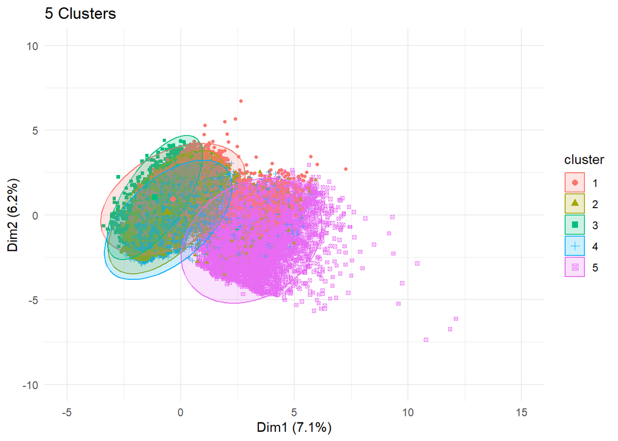

```r
Cluster5
```

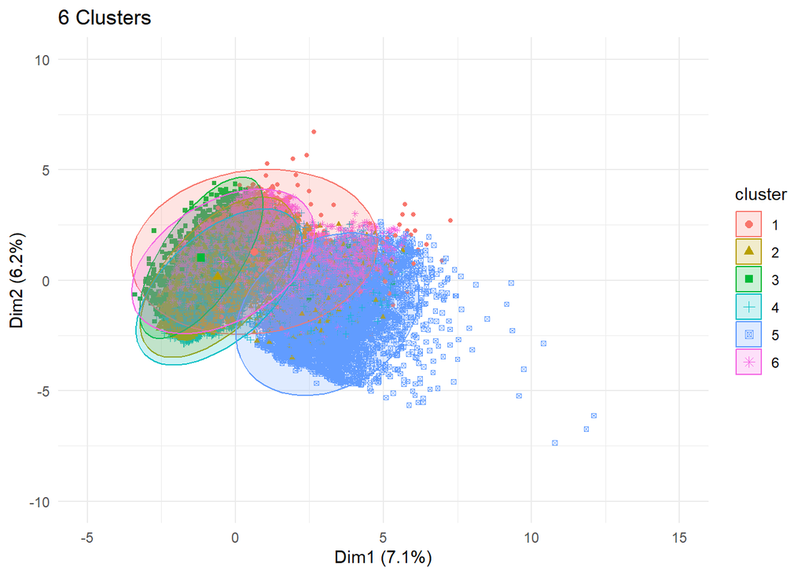

```r
Cluster6
```

**Based on the cluster plot, it seems that customers should be divided into 3 clusters.**

## Cluster Size Plots

```r
# Cluster size of each cluster
sizes4k <- data.frame(Size = StrattonCluster_4k[["size"]],
                      Cluster = c("Cluster1", "Cluster2", "Cluster3", "Cluster4"))

size4 <- ggplot(sizes4k, aes(factor(Cluster), Size)) +
  geom_col(aes(fill = Cluster)) +
  xlab("Cluster") +
  ylab("Size") +
  geom_text(aes(label=Size), vjust = -0.2) +
  ggtitle("Cluster Size 4-Clusters") +
  theme(axis.text.x = element_text(angle = 45, hjust = 1)) +
  scale_fill_brewer(palette = "Paired")
```

[figure not shown]

```r
sizes5k <- data.frame(Size = StrattonCluster_5k[["size"]],
                      Cluster = c("Cluster1", "Cluster2", "Cluster3", "Cluster4", "Cluster5"))

size5 <- ggplot(sizes5k, aes(factor(Cluster), Size)) +
  geom_col(aes(fill = Cluster)) +
  xlab("Cluster") +
  ylab("Size") +
  geom_text(aes(label=Size), vjust = -0.2) +
  ggtitle("Cluster Size 5-Clusters") +
  theme(axis.text.x = element_text(angle = 45, hjust = 1)) +
  scale_fill_brewer(palette = "Paired")
```

```r
# Include Clusters into original data
bank <- bank %>%
  mutate(k3Cluster = as.factor(StrattonCluster_3k[["cluster"]]),
         k4Cluster = as.factor(StrattonCluster_4k[["cluster"]]),
         k5Cluster = as.factor(StrattonCluster_5k[["cluster"]]),
         k6Cluster = as.factor(StrattonCluster_6k[["cluster"]]))
```

## Subscription Rate Per Cluster Plots

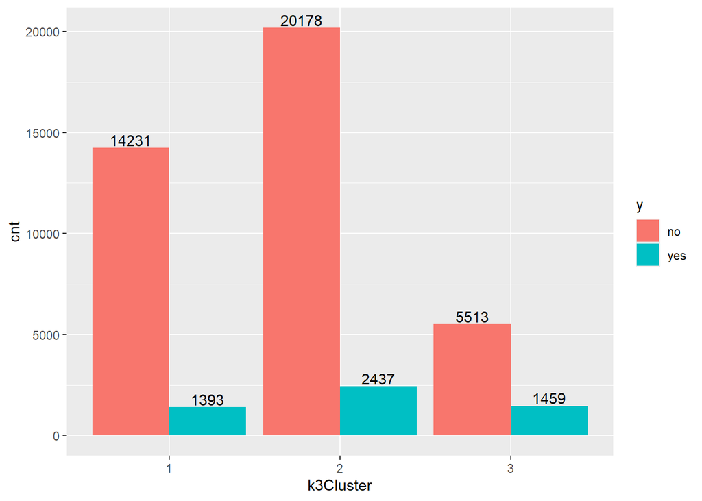

```r
bank %>%
  group_by(k3Cluster, y) %>%
  summarise(cnt = n()) %>%
  ggplot(aes(x=k3Cluster, y=cnt, fill=y)) +
  geom_bar(stat="identity", position="dodge") +
  geom_text(aes(label=cnt), position = position_dodge(width = 0.9), vjust=-0.2)
```

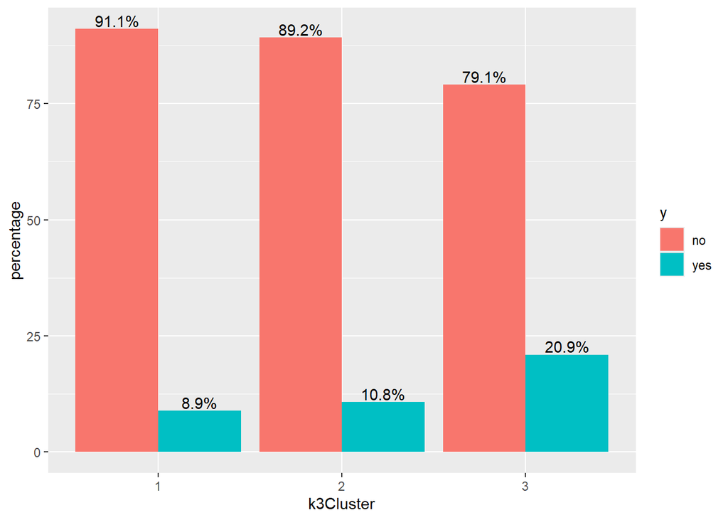

```r
bank %>%
  group_by(k3Cluster, y) %>%
  summarise(cnt = n()) %>%
  ungroup() %>%
  group_by(k3Cluster) %>%
  mutate(total = sum(cnt),
         percentage = cnt / total * 100) %>%
  ggplot(aes(x=k3Cluster, y=percentage, fill=y)) +
  geom_bar(stat="identity", position="dodge") +
  geom_text(aes(label=paste0(round(percentage,1), "%")), position = position_dodge(width = 0.9), vjust=-0.2)
```

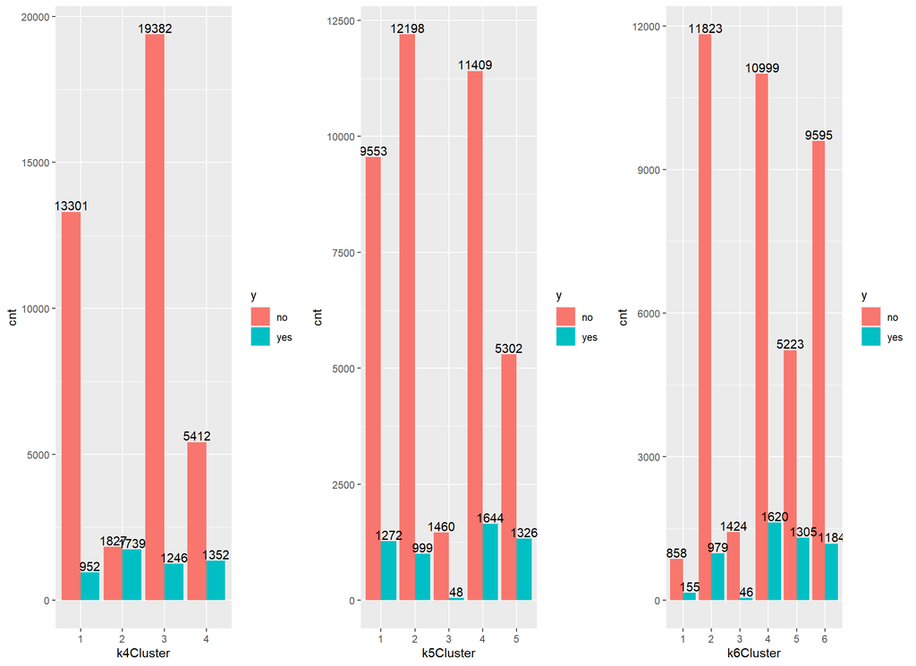

```r
# 4 Clusters
ycount4 <- bank %>%
  group_by(k4Cluster, y) %>%
  summarise(cnt = n()) %>%
  ggplot(aes(x=k4Cluster, y=cnt, fill=y)) +
  geom_bar(stat="identity", position="dodge") +
  geom_text(aes(label=cnt), position = position_dodge(width = 0.9), vjust=-0.2)
y4 <- bank %>%
  group_by(k4Cluster, y) %>%
  summarise(cnt = n()) %>%
  ungroup() %>%
  group_by(k4Cluster) %>%
  mutate(total = sum(cnt),
         percentage = cnt / total * 100) %>%
  ggplot(aes(x=k4Cluster, y=percentage, fill=y)) +
  geom_bar(stat="identity", position="dodge") +
  ggtitle("Subsciption Rate 4 Clusters") +
  geom_text(aes(label=paste0(round(percentage,1), "%")), position = position_dodge(width = 0.9), vjust=-0.2)
# 5 Clusters
ycount5 <- bank %>%
  group_by(k5Cluster, y) %>%
  summarise(cnt = n()) %>%
  ggplot(aes(x=k5Cluster, y=cnt, fill=y)) +
  geom_bar(stat="identity", position="dodge") +
  geom_text(aes(label=cnt), position = position_dodge(width = 0.9), vjust=-0.2)
y5 <- bank %>%
  group_by(k5Cluster, y) %>%
  summarise(cnt = n()) %>%
  ungroup() %>%
  group_by(k5Cluster) %>%
  mutate(total = sum(cnt),
         percentage = cnt / total * 100) %>%
  ggplot(aes(x=k5Cluster, y=percentage, fill=y)) +
  geom_bar(stat="identity", position="dodge") +
  ggtitle("Subsciption Rate 5 Clusters") +
  geom_text(aes(label=paste0(round(percentage,1), "%")), position = position_dodge(width = 0.9), vjust=-0.2)
# 6 Clusters
ycount6 <- bank %>%
  group_by(k6Cluster, y) %>%
  summarise(cnt = n()) %>%
  ggplot(aes(x=k6Cluster, y=cnt, fill=y)) +
  geom_bar(stat="identity", position="dodge") +
  geom_text(aes(label=cnt), position = position_dodge(width = 0.9), vjust=-0.2)
y6 <- bank %>%
  group_by(k6Cluster, y) %>%
  summarise(cnt = n()) %>%
  ungroup() %>%
  group_by(k6Cluster) %>%
  mutate(total = sum(cnt),
         percentage = cnt / total * 100) %>%
  ggplot(aes(x=k6Cluster, y=percentage, fill=y)) +
  geom_bar(stat="identity", position="dodge") +
  ggtitle("Subsciption Rate 6 Clusters") +
  geom_text(aes(label=paste0(round(percentage,1), "%")), position = position_dodge(width = 0.9), vjust=-0.2)
grid.arrange(ycount4, ycount5, ycount6, ncol=3, nrow = 1)
```

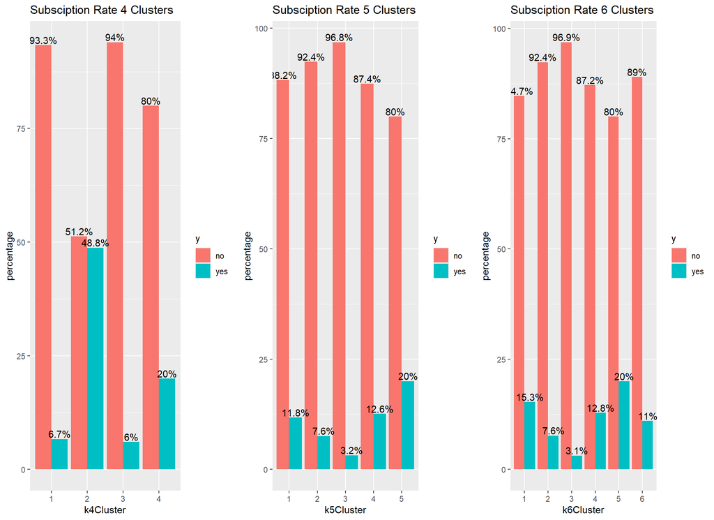

```r
grid.arrange(y4, y5, y6, ncol=3, nrow = 1)
```

## Cluster Mean Plots and Cluster Profile

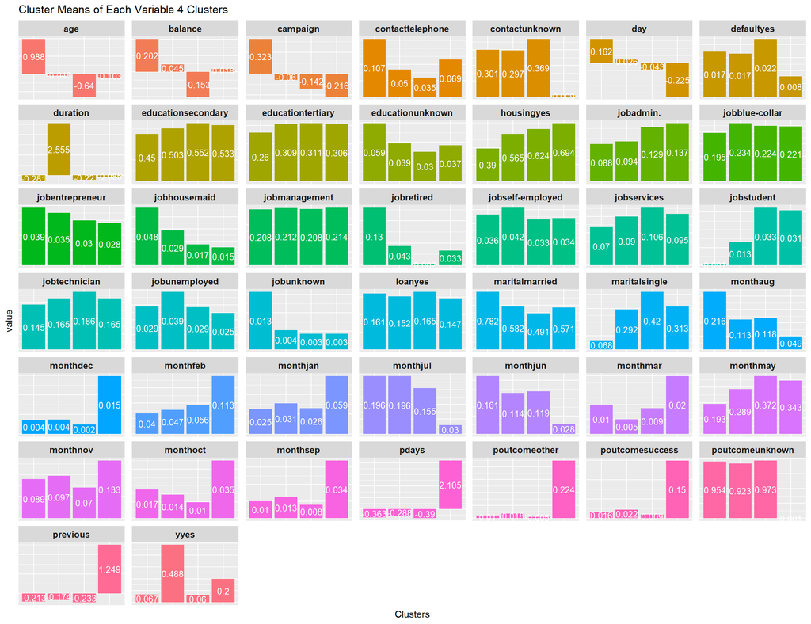

```r
# 4 Clusters
# Build Mean per Cluster DataFrame
scaled_bank_dummies$k4Cluster = StrattonCluster_4k[["cluster"]]

summarystats.percluster_4k = scaled_bank_dummies %>% group_by(k4Cluster) %>%
  summarise_if(is.numeric, mean, na.rm = TRUE)

var <- summarystats.percluster_4k %>%
  gather(key = "variable", value = "value", -k4Cluster)

ggplot(var, aes(factor(k4Cluster), value)) +
  geom_bar(stat = "identity", aes(fill = variable), show.legend = FALSE)  +
  xlab("Clusters") +
  geom_text(aes(label = round(value, digits = 3)), size = 3.5, colour = "white",
            position = position_stack(vjust = 0.5)) +
  ggtitle("Cluster Means of Each Variable 4 Clusters") +
  facet_wrap(~variable, ncol=7, scales = "free_y") +
  theme(strip.text = element_text(size = 10, face = "bold"),
        axis.text.x = element_blank(),
        axis.ticks.x = element_blank(),
        axis.text.y = element_blank(),
        axis.ticks.y = element_blank())
```

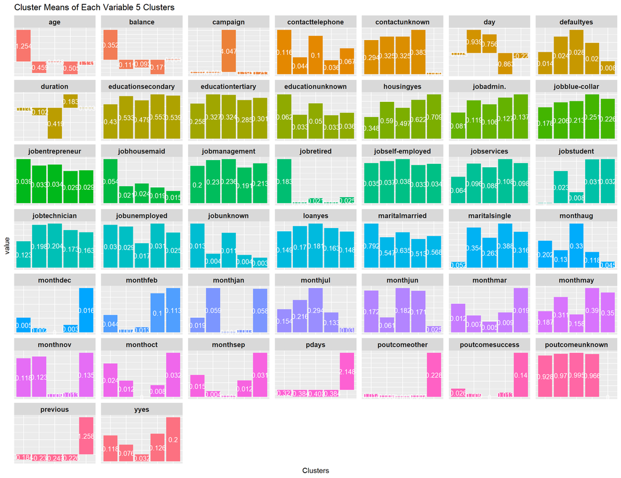

```r
# 5 Clusters
# Build Mean per Cluster DataFrame
scaled_bank_dummies$k5Cluster = StrattonCluster_5k[["cluster"]]

summarystats.percluster_5k = scaled_bank_dummies %>% group_by(k5Cluster) %>%
  summarise_if(is.numeric, mean, na.rm = TRUE)

var <- summarystats.percluster_5k %>%
  gather(key = "variable", value = "value", -k4Cluster, -k5Cluster)

ggplot(var, aes(factor(k5Cluster), value)) +
  geom_bar(stat = "identity", aes(fill = variable), show.legend = FALSE)  +
  xlab("Clusters") +
  geom_text(aes(label = round(value, digits = 3)), size = 3.5, colour = "white",
            position = position_stack(vjust = 0.5)) +
  ggtitle("Cluster Means of Each Variable 5 Clusters") +
  facet_wrap(~variable, ncol=7, scales = "free_y") +
  theme(strip.text = element_text(size = 10, face = "bold"),
        axis.text.x = element_blank(),
        axis.ticks.x = element_blank(),
        axis.text.y = element_blank(),
        axis.ticks.y = element_blank())
```

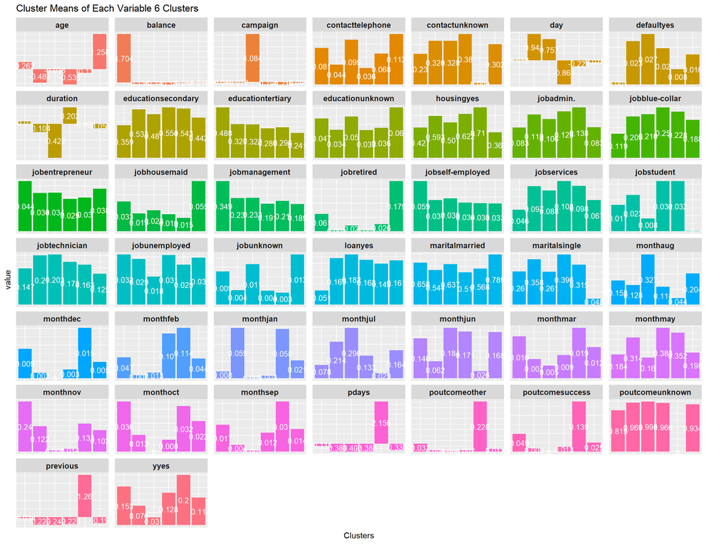

```r
# 6 Clusters
# Build Mean per Cluster DataFrame
scaled_bank_dummies$k6Cluster = StrattonCluster_6k[["cluster"]]

summarystats.percluster_6k = scaled_bank_dummies %>% group_by(k6Cluster) %>%
  summarise_if(is.numeric, mean, na.rm = TRUE)

var <- summarystats.percluster_6k %>%
  gather(key = "variable", value = "value", -k4Cluster, -k5Cluster, -k6Cluster)

ggplot(var, aes(factor(k6Cluster), value)) +
  geom_bar(stat = "identity", aes(fill = variable), show.legend = FALSE)  +
  xlab("Clusters") +
  geom_text(aes(label = round(value, digits = 3)), size = 3.5, colour = "white",
            position = position_stack(vjust = 0.5)) +
  ggtitle("Cluster Means of Each Variable 6 Clusters") +
  facet_wrap(~variable, ncol=7, scales = "free_y") +
  theme(strip.text = element_text(size = 10, face = "bold"),
        axis.text.x = element_blank(),
        axis.ticks.x = element_blank(),
        axis.text.y = element_blank(),
        axis.ticks.y = element_blank())
```

## Cluster 2 Logistic

```r
bank$y <- ifelse(bank$y=="yes", 1, 0) %>% as.factor(.) # 1=yes,0=no

# full model
bank1 <- bank %>%
  select(-k3Cluster, -k5Cluster, -k6Cluster) %>%
  filter(k4Cluster == 2) %>%
  select(-k4Cluster)

logistic_cluster2 <- glm(y ~ ., data = bank1, family = "binomial")

summary(logistic_cluster2)
```

```
##
## Call:
## glm(formula = y ~ ., family = "binomial", data = bank1)
##
## Deviance Residuals:
##     Min       1Q   Median       3Q      Max
## -2.3623  -1.0634  -0.7036   1.1213   1.9205
##
## Coefficients:
##                      Estimate Std. Error z value Pr(>|z|)
## (Intercept)         1.101e+00  5.662e-01   1.944 0.051931 .
## age                -7.273e-03  4.509e-03  -1.613 0.106758
## jobblue-collar     -3.227e-01  1.412e-01  -2.285 0.022306 *
## jobentrepreneur    -2.356e-01  2.251e-01  -1.047 0.295192
## jobhousemaid       -9.453e-01  2.547e-01  -3.711 0.000206 ***
## jobmanagement      -3.580e-01  1.606e-01  -2.229 0.025782 *
## jobretired          8.686e-02  2.273e-01   0.382 0.702322
## jobself-employed   -3.015e-01  2.121e-01  -1.421 0.155327
## jobservices        -2.550e-01  1.636e-01  -1.558 0.119135
## jobstudent          3.758e-01  3.735e-01   1.006 0.314449
## jobtechnician      -2.533e-01  1.464e-01  -1.730 0.083659 .
## jobunemployed      -2.995e-01  2.185e-01  -1.371 0.170456
## jobunknown         -4.063e-01  5.747e-01  -0.707 0.479575
## maritalmarried     -4.178e-01  1.109e-01  -3.769 0.000164 ***
## maritalsingle      -3.910e-02  1.264e-01  -0.309 0.757042
## educationsecondary -7.380e-02  1.131e-01  -0.653 0.513968
## educationtertiary  -2.607e-03  1.421e-01  -0.018 0.985357
## educationunknown   -3.335e-01  2.120e-01  -1.574 0.115602
## defaultyes          1.489e-01  2.741e-01   0.543 0.586879
## balance             4.242e-06  1.254e-05   0.338 0.735113
## housingyes         -1.943e-01  8.582e-02  -2.264 0.023562 *
## loanyes             1.197e-02  1.011e-01   0.118 0.905782
## contacttelephone   -2.764e-01  1.707e-01  -1.619 0.105384
## contactunknown     -1.213e+00  1.301e-01  -9.320  < 2e-16 ***
## day                 1.265e-02  5.137e-03   2.462 0.013826 *
## monthfeb            8.912e-01  2.843e-01   3.135 0.001718 **
## monthmar            3.095e+00  8.000e-01   3.869 0.000109 ***
## monthapr            7.951e-01  2.489e-01   3.195 0.001397 **
## monthmay            1.400e+00  2.471e-01   5.664 1.48e-08 ***
## monthjun            1.888e+00  2.792e-01   6.764 1.34e-11 ***
```

[output cut: 8 more lines]

```
## pdays              -2.091e-03  1.439e-03  -1.453 0.146211
## previous           -7.899e-02  8.154e-02  -0.969 0.332672
## poutcomefailure    -1.363e+00  3.716e-01  -3.668 0.000245 ***
## poutcomeunknown    -1.851e+00  4.358e-01  -4.247 2.17e-05 ***
## poutcomeother      -1.563e+00  4.153e-01  -3.763 0.000168 ***
## ---
## Signif. codes:  0 '***' 0.001 '**' 0.01 '*' 0.05 '.' 0.1 ' ' 1
##
## (Dispersion parameter for binomial family taken to be 1)
##
##     Null deviance: 4941.4  on 3565  degrees of freedom
## Residual deviance: 4596.9  on 3523  degrees of freedom
## AIC: 4682.9
##
## Number of Fisher Scoring iterations: 4
```

```r
library(performance)
check_collinearity(logistic_cluster2)
```

```
## # Check for Multicollinearity
##
## Low Correlation
##
##       Term  VIF   VIF 95% CI Increased SE Tolerance Tolerance 95% CI
##        age 1.58 [1.52, 1.66]         1.26      0.63     [0.60, 0.66]
##        job 3.59 [3.40, 3.80]         1.90      0.28     [0.26, 0.29]
##    marital 1.25 [1.21, 1.31]         1.12      0.80     [0.77, 0.83]
##  education 2.39 [2.28, 2.52]         1.55      0.42     [0.40, 0.44]
##    default 1.03 [1.01, 1.10]         1.01      0.97     [0.91, 0.99]
##    balance 1.06 [1.03, 1.11]         1.03      0.94     [0.90, 0.97]
##    housing 1.46 [1.41, 1.53]         1.21      0.68     [0.65, 0.71]
##       loan 1.09 [1.06, 1.13]         1.04      0.92     [0.88, 0.95]
##    contact 3.03 [2.87, 3.20]         1.74      0.33     [0.31, 0.35]
##        day 1.41 [1.35, 1.47]         1.19      0.71     [0.68, 0.74]
##   duration 1.07 [1.04, 1.12]         1.03      0.94     [0.89, 0.96]
##   campaign 1.12 [1.08, 1.16]         1.06      0.90     [0.86, 0.92]
##      pdays 3.99 [3.77, 4.23]         2.00      0.25     [0.24, 0.27]
##   previous 2.85 [2.70, 3.01]         1.69      0.35     [0.33, 0.37]
##
## Moderate Correlation
##
##      Term  VIF   VIF 95% CI Increased SE Tolerance Tolerance 95% CI
##     month 7.31 [6.88, 7.76]         2.70      0.14     [0.13, 0.15]
##  poutcome 6.70 [6.31, 7.12]         2.59      0.15     [0.14, 0.16]
```

```r
# Remove month and poutcome
cluster2 <- bank1 %>%
  select(-month, -poutcome)

# Train the logistic regression model using Cluster 2
logistic_cluster2 <- glm(y ~ ., data = cluster2, family = "binomial")

summary(logistic_cluster2)
```

```
##
## Call:
## glm(formula = y ~ ., family = "binomial", data = cluster2)
##
## Deviance Residuals:
##     Min       1Q   Median       3Q      Max
## -2.2805  -1.1031  -0.7725   1.1346   1.7830
##
## Coefficients:
##                      Estimate Std. Error z value Pr(>|z|)
## (Intercept)         4.043e-01  3.010e-01   1.344 0.179100
## age                -4.739e-03  4.398e-03  -1.077 0.281261
## jobblue-collar     -3.148e-01  1.390e-01  -2.265 0.023531 *
## jobentrepreneur    -2.923e-01  2.218e-01  -1.318 0.187495
## jobhousemaid       -8.183e-01  2.469e-01  -3.315 0.000918 ***
## jobmanagement      -3.469e-01  1.575e-01  -2.203 0.027616 *
## jobretired          1.922e-01  2.213e-01   0.869 0.385115
## jobself-employed   -3.291e-01  2.087e-01  -1.577 0.114802
## jobservices        -2.314e-01  1.613e-01  -1.435 0.151390
## jobstudent          4.748e-01  3.664e-01   1.296 0.195107
## jobtechnician      -2.331e-01  1.433e-01  -1.627 0.103803
## jobunemployed      -3.671e-01  2.127e-01  -1.726 0.084321 .
## jobunknown         -6.158e-01  5.619e-01  -1.096 0.273093
## maritalmarried     -4.025e-01  1.087e-01  -3.704 0.000212 ***
## maritalsingle      -2.705e-02  1.239e-01  -0.218 0.827256
## educationsecondary -6.196e-02  1.114e-01  -0.556 0.578123
## educationtertiary   7.844e-02  1.395e-01   0.562 0.573806
## educationunknown   -2.753e-01  2.087e-01  -1.319 0.187120
## defaultyes          1.620e-01  2.712e-01   0.597 0.550394
## balance             1.962e-06  1.217e-05   0.161 0.871926
## housingyes         -2.598e-01  7.516e-02  -3.456 0.000549 ***
## loanyes            -8.175e-02  9.821e-02  -0.832 0.405188
## contacttelephone   -2.850e-01  1.659e-01  -1.718 0.085770 .
## contactunknown     -6.007e-01  8.105e-02  -7.412 1.25e-13 ***
## day                -4.668e-03  4.317e-03  -1.081 0.279540
## duration            7.183e-04  1.035e-04   6.940 3.92e-12 ***
## campaign            1.603e-03  1.423e-02   0.113 0.910315
## pdays              -2.658e-04  9.437e-04  -0.282 0.778192
## previous            8.173e-02  6.228e-02   1.312 0.189375
## ---
## Signif. codes:  0 '***' 0.001 '**' 0.01 '*' 0.05 '.' 0.1 ' ' 1
##
## (Dispersion parameter for binomial family taken to be 1)
##
##     Null deviance: 4941.4  on 3565  degrees of freedom
## Residual deviance: 4714.0  on 3537  degrees of freedom
## AIC: 4772
##
## Number of Fisher Scoring iterations: 4
```

```r
library(performance)
check_collinearity(logistic_cluster2)
```

```
## # Check for Multicollinearity
##
## Low Correlation
##
##       Term  VIF   VIF 95% CI Increased SE Tolerance Tolerance 95% CI
##        age 1.59 [1.52, 1.66]         1.26      0.63     [0.60, 0.66]
##        job 3.25 [3.08, 3.43]         1.80      0.31     [0.29, 0.33]
##    marital 1.23 [1.19, 1.29]         1.11      0.81     [0.78, 0.84]
##  education 2.36 [2.25, 2.49]         1.54      0.42     [0.40, 0.44]
##    default 1.02 [1.01, 1.10]         1.01      0.98     [0.91, 0.99]
##    balance 1.04 [1.01, 1.10]         1.02      0.96     [0.91, 0.99]
##    housing 1.16 [1.12, 1.21]         1.08      0.86     [0.83, 0.89]
##       loan 1.04 [1.02, 1.10]         1.02      0.96     [0.91, 0.98]
##    contact 1.17 [1.13, 1.22]         1.08      0.85     [0.82, 0.88]
##        day 1.03 [1.01, 1.10]         1.01      0.97     [0.91, 0.99]
##   duration 1.05 [1.02, 1.10]         1.02      0.95     [0.91, 0.98]
##   campaign 1.04 [1.01, 1.10]         1.02      0.96     [0.91, 0.99]
##      pdays 1.84 [1.75, 1.93]         1.35      0.54     [0.52, 0.57]
##   previous 1.80 [1.72, 1.89]         1.34      0.56     [0.53, 0.58]
```

```r
# Odds Ratio
exp(cbind(OR=coef(logistic_cluster2), confint(logistic_cluster2)))
```

```
##                           OR     2.5 %    97.5 %
## (Intercept)        1.4983138 0.8307636 2.7037794
## age                0.9952721 0.9867233 1.0038875
## jobblue-collar     0.7299010 0.5555288 0.9582752
## jobentrepreneur    0.7465103 0.4825323 1.1523882
## jobhousemaid       0.4411852 0.2701519 0.7123237
## jobmanagement      0.7068560 0.5187541 0.9620513
## jobretired         1.2119147 0.7861955 1.8732248
## jobself-employed   0.7195550 0.4774344 1.0828501
## jobservices        0.7934151 0.5780155 1.0881003
## jobstudent         1.6076185 0.8034335 3.4153539
## jobtechnician      0.7920793 0.5978033 1.0485950
## jobunemployed      0.6927205 0.4561530 1.0509510
## jobunknown         0.5402119 0.1706457 1.6078857
## maritalmarried     0.6686271 0.5400782 0.8270770
## maritalsingle      0.9733146 0.7630840 1.2406638
## educationsecondary 0.9399174 0.7555529 1.1695364
## educationtertiary  1.0815954 0.8229824 1.4219211
## educationunknown   0.7593348 0.5028958 1.1409635
## defaultyes         1.1758132 0.6898886 2.0075420
## balance            1.0000020 0.9999780 1.0000259
## housingyes         0.7712400 0.6655383 0.8936198
## loanyes            0.9214993 0.7598640 1.1168769
## contacttelephone   0.7520233 0.5426657 1.0406115
## contactunknown     0.5484219 0.4676459 0.6425688
## day                0.9953427 0.9869512 1.0037981
## duration           1.0007185 1.0005181 1.0009243
## campaign           1.0016044 0.9736345 1.0298259
## pdays              0.9997342 0.9978894 1.0016017
## previous           1.0851669 0.9627390 1.2305076
```

# 4. Lasso Variable Selection

## Split data into training dataset and testing dataset

```r
# remove clusters
bank <- bank %>% select(-k3Cluster, -k4Cluster, -k5Cluster, -k6Cluster)

# Split the data into two sets based on the value of y
bank_y1 <- bank %>% filter(y == 1)
bank_y0 <- bank %>% filter(y == 0)

# Function to split data into train (80%) and test (20%) using caret
split_data <- function(data, train_ratio = 0.8) {
  set.seed(208) # For reproducibility
  train_indices <- createDataPartition(data$y, p = train_ratio, list = FALSE)

  train_set <- data[train_indices, ]
  test_set <- data[-train_indices, ]

  list(train = train_set, test = test_set)
}

# Split each dataset into train and test sets
split_y1 <- split_data(bank_y1)
split_y0 <- split_data(bank_y0)

# Extract train and test sets
train_y1 <- split_y1$train
test_y1 <- split_y1$test
train_y0 <- split_y0$train
test_y0 <- split_y0$test

# Combine the train and test sets
train_data <- bind_rows(train_y1, train_y0)
test_data <- bind_rows(test_y1, test_y0)
```

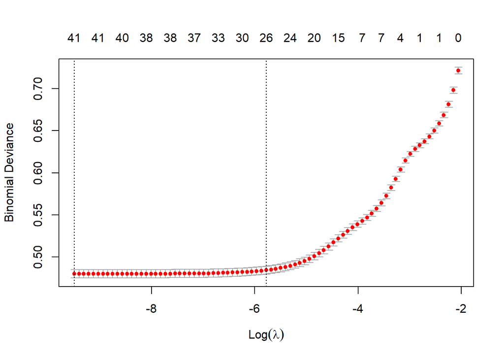

```r
x <- model.matrix(y ~ ., train_data)[, -17]
y <- train_data$y

cv.lasso <- cv.glmnet(x, y, alpha = 1, family = "binomial")
plot(cv.lasso)
```

```r
# exact value of lambda
cv.lasso$lambda.min
```

```
## [1] 7.487831e-05
```

```r
# Final model with lambda.min
lasso_model <- glmnet(x, y, alpha = 1, family = "binomial",
                      lambda = cv.lasso$lambda.min)
lasso_model
```

```
##
## Call:  glmnet(x = x, y = y, family = "binomial", alpha = 1, lambda = cv.lasso$lambda.min)
##
##   Df  %Dev    Lambda
## 1 41 33.87 7.488e-05
```

```r
coef(lasso_model, lasso_model$lambda.min)
```

```
## 43 x 1 sparse Matrix of class "dgCMatrix"
##                               s0
## (Intercept)        -9.291168e-01
## (Intercept)         .
## age                -2.033663e-03
## jobblue-collar     -3.525898e-01
## jobentrepreneur    -3.023273e-01
## jobhousemaid       -5.576261e-01
## jobmanagement      -1.659069e-02
## jobretired          2.752205e-01
## jobself-employed   -1.394618e-01
## jobservices        -2.087772e-01
## jobstudent          3.452913e-01
## jobtechnician      -1.459844e-01
## jobunemployed      -6.604177e-02
## jobunknown         -3.695652e-01
## maritalmarried     -1.816724e-01
## maritalsingle       8.152557e-02
## educationsecondary -2.010157e-02
## educationunknown    3.292698e-02
## defaultyes         -1.217850e-01
## balance             1.648555e-05
## housingyes         -7.131975e-01
## loanyes            -4.082641e-01
## contacttelephone   -1.678085e-01
## contactunknown     -1.615159e+00
## day                 5.390038e-03
## monthfeb            7.659520e-01
## monthmar            2.590788e+00
## monthapr            9.885731e-01
## monthmay            5.764715e-01
## monthjun            1.387814e+00
## monthjul            1.704651e-01
## monthaug            2.766837e-01
## monthsep            1.871558e+00
## monthoct            1.824289e+00
## monthnov            1.691982e-01
## monthdec            1.745887e+00
## duration            4.223889e-03
## campaign           -9.426637e-02
## pdays              -1.281590e-04
## previous            1.161780e-02
## poutcomefailure    -2.238261e+00
## poutcomeunknown    -2.308462e+00
## poutcomeother      -2.042925e+00
```

```r
# Make prediction on test data
x.test <- model.matrix(y ~ ., test_data)[, -17]
y.test <- test_data$y

pred_prob <- lasso_model %>% predict(newx = x.test)
pred_class <- ifelse(pred_prob > 0.8, 1, 0)

# Evaluate the model
confusionMatrix(as.factor(pred_class), as.factor(y.test), mode = "everything", positive = "1")
```

```
## Confusion Matrix and Statistics
##
##           Reference
## Prediction    0    1
##          0 7889  818
##          1   95  239
##
##                Accuracy : 0.899
##                  95% CI : (0.8926, 0.9052)
##     No Information Rate : 0.8831
##     P-Value [Acc > NIR] : 8.309e-07
##
##                   Kappa : 0.3046
##
##  Mcnemar's Test P-Value : < 2.2e-16
##
##             Sensitivity : 0.22611
##             Specificity : 0.98810
##          Pos Pred Value : 0.71557
##          Neg Pred Value : 0.90605
##               Precision : 0.71557
##                  Recall : 0.22611
##                      F1 : 0.34364
##              Prevalence : 0.11691
##          Detection Rate : 0.02644
##    Detection Prevalence : 0.03694
##       Balanced Accuracy : 0.60711
##
##        'Positive' Class : 1
##
```

# 5. Predictive Modeling

## 5.1 Logistic Regression Analysis

### One Time Logistic

```r
# Train the logistic regression model using Cluster 2
logistic_model <- glm(y ~ ., data = bank, family = "binomial")

summary(logistic_model)
```

```
##
## Call:
## glm(formula = y ~ ., family = "binomial", data = bank)
##
## Deviance Residuals:
##     Min       1Q   Median       3Q      Max
## -5.7286  -0.3744  -0.2530  -0.1502   3.4288
##
## Coefficients:
##                      Estimate Std. Error z value Pr(>|z|)
## (Intercept)        -1.506e+00  2.044e-01  -7.371 1.69e-13 ***
## age                 1.127e-04  2.205e-03   0.051 0.959233
## jobblue-collar     -3.099e-01  7.267e-02  -4.264 2.01e-05 ***
## jobentrepreneur    -3.571e-01  1.256e-01  -2.844 0.004455 **
## jobhousemaid       -5.040e-01  1.365e-01  -3.693 0.000221 ***
## jobmanagement      -1.653e-01  7.329e-02  -2.255 0.024130 *
## jobretired          2.524e-01  9.722e-02   2.596 0.009436 **
## jobself-employed   -2.983e-01  1.120e-01  -2.664 0.007726 **
## jobservices        -2.238e-01  8.406e-02  -2.662 0.007763 **
## jobstudent          3.821e-01  1.090e-01   3.505 0.000457 ***
## jobtechnician      -1.760e-01  6.893e-02  -2.554 0.010664 *
## jobunemployed      -1.767e-01  1.116e-01  -1.583 0.113456
## jobunknown         -3.133e-01  2.335e-01  -1.342 0.179656
## maritalmarried     -1.795e-01  5.891e-02  -3.046 0.002318 **
## maritalsingle       9.250e-02  6.726e-02   1.375 0.169066
## educationsecondary  1.835e-01  6.479e-02   2.833 0.004618 **
## educationtertiary   3.789e-01  7.532e-02   5.031 4.88e-07 ***
## educationunknown    2.505e-01  1.039e-01   2.411 0.015915 *
## defaultyes         -1.668e-02  1.628e-01  -0.102 0.918407
## balance             1.283e-05  5.148e-06   2.493 0.012651 *
## housingyes         -6.754e-01  4.387e-02 -15.395  < 2e-16 ***
## loanyes            -4.254e-01  5.999e-02  -7.091 1.33e-12 ***
## contacttelephone   -1.634e-01  7.519e-02  -2.173 0.029784 *
## contactunknown     -1.623e+00  7.317e-02 -22.184  < 2e-16 ***
## day                 9.969e-03  2.497e-03   3.993 6.53e-05 ***
## monthfeb            1.114e+00  1.321e-01   8.435  < 2e-16 ***
## monthmar            2.852e+00  1.522e-01  18.735  < 2e-16 ***
## monthapr            1.262e+00  1.217e-01  10.367  < 2e-16 ***
## monthmay            8.626e-01  1.210e-01   7.131 9.96e-13 ***
## monthjun            1.715e+00  1.342e-01  12.781  < 2e-16 ***
```

[output cut: 8 more lines]

```
## pdays              -1.027e-04  3.061e-04  -0.335 0.737268
## previous            1.015e-02  6.503e-03   1.561 0.118476
## poutcomefailure    -2.291e+00  8.235e-02 -27.821  < 2e-16 ***
## poutcomeunknown    -2.383e+00  8.625e-02 -27.627  < 2e-16 ***
## poutcomeother      -2.088e+00  9.838e-02 -21.218  < 2e-16 ***
## ---
## Signif. codes:  0 '***' 0.001 '**' 0.01 '*' 0.05 '.' 0.1 ' ' 1
##
## (Dispersion parameter for binomial family taken to be 1)
##
##     Null deviance: 32631  on 45210  degrees of freedom
## Residual deviance: 21562  on 45168  degrees of freedom
## AIC: 21648
##
## Number of Fisher Scoring iterations: 6
```

```r
# Check for Multicollinearity
library(performance)
check_collinearity(logistic_model)
```

```
## # Check for Multicollinearity
##
## Low Correlation
##
##       Term  VIF   VIF 95% CI Increased SE Tolerance Tolerance 95% CI
##        age 2.18 [2.15, 2.21]         1.48      0.46     [0.45, 0.47]
##        job 4.17 [4.10, 4.23]         2.04      0.24     [0.24, 0.24]
##    marital 1.44 [1.43, 1.46]         1.20      0.69     [0.68, 0.70]
##  education 2.26 [2.23, 2.29]         1.50      0.44     [0.44, 0.45]
##    default 1.02 [1.01, 1.03]         1.01      0.98     [0.97, 0.99]
##    balance 1.04 [1.03, 1.05]         1.02      0.96     [0.95, 0.97]
##    housing 1.43 [1.41, 1.45]         1.20      0.70     [0.69, 0.71]
##       loan 1.06 [1.05, 1.08]         1.03      0.94     [0.93, 0.95]
##    contact 1.90 [1.88, 1.93]         1.38      0.53     [0.52, 0.53]
##        day 1.34 [1.33, 1.36]         1.16      0.74     [0.74, 0.75]
##      month 3.74 [3.69, 3.81]         1.94      0.27     [0.26, 0.27]
##   duration 1.13 [1.12, 1.14]         1.06      0.89     [0.88, 0.90]
##   campaign 1.11 [1.10, 1.12]         1.05      0.90     [0.89, 0.91]
##      pdays 3.67 [3.61, 3.72]         1.91      0.27     [0.27, 0.28]
##   previous 1.28 [1.26, 1.29]         1.13      0.78     [0.77, 0.79]
##   poutcome 4.22 [4.15, 4.29]         2.05      0.24     [0.23, 0.24]
```

```r
# Odds Ratio
exp(cbind(OR=coef(logistic_model), confint(logistic_model)))
```

```
##                             OR       2.5 %     97.5 %
## (Intercept)         0.22172874  0.14834373  0.3305304
## age                 1.00011272  0.99579484  1.0044404
## jobblue-collar      0.73354041  0.63619029  0.8458978
## jobentrepreneur     0.69969989  0.54501401  0.8918390
## jobhousemaid        0.60410838  0.46034885  0.7862107
## jobmanagement       0.84765765  0.73444135  0.9789102
## jobretired          1.28706269  1.06345615  1.5568293
## jobself-employed    0.74205191  0.59453799  0.9223659
## jobservices         0.79947733  0.67755374  0.9420831
## jobstudent          1.46541095  1.18253319  1.8132591
## jobtechnician       0.83860411  0.73274395  0.9601033
## jobunemployed       0.83802016  0.67199160  1.0410793
## jobunknown          0.73105661  0.45554442  1.1393971
## maritalmarried      0.83572682  0.74509304  0.9386717
## maritalsingle       1.09691056  0.96189859  1.2521250
## educationsecondary  1.20144892  1.05881708  1.3650198
## educationtertiary   1.46073758  1.26082361  1.6939086
## educationunknown    1.28464040  1.04666688  1.5729866
## defaultyes          0.98345715  0.70676108  1.3394461
## balance             1.00001284  1.00000258  1.0000228
## housingyes          0.50896077  0.46695836  0.5545819
## loanyes             0.65352685  0.58042224  0.7343275
## contacttelephone    0.84927322  0.73190093  0.9828158
## contactunknown      0.19726311  0.17077648  0.2275174
## day                 1.01001878  1.00508864  1.0149739
## monthfeb            3.04773246  2.35782841  3.9585000
## monthmar           17.31562612 12.87397469 23.3840043
## monthapr            3.53148618  2.79005430  4.4967452
## monthmay            2.36933037  1.87478455  3.0128593
## monthjun            5.55857286  4.28303602  7.2497782
## monthjul            1.53867738  1.22020840  1.9520092
## monthaug            1.76440098  1.39557482  2.2440746
## monthsep            8.46361890  6.29123560 11.4261413
## monthoct            8.52630617  6.47951116 11.2660475
## monthnov            1.47450195  1.15777998  1.8876649
## monthdec            7.04869941  4.76645898 10.4238777
## duration            1.00420250  1.00407617  1.0043302
## campaign            0.91321697  0.89498330  0.9312596
## pdays               0.99989732  0.99929562  1.0004956
## previous            1.01020406  0.99767302  1.0257841
## poutcomefailure     0.10115958  0.08602335  0.1188017
## poutcomeunknown     0.09228723  0.07792031  0.1092942
## poutcomeother       0.12398712  0.10212121  0.1501869
```

### 10-fold Cross Validation

```r
# Set up 10-fold cross-validation
train_control <- trainControl(method = "cv", number = 10)

# Train the logistic regression model using 10-fold cross-validation
logistic_model_cv <- train(y ~ ., data = train_data, method = "glm", family = "binomial", trControl = train_control)

# Display the results
summary(logistic_model_cv)
```

```
##
## Call:
## NULL
##
## Deviance Residuals:
##     Min       1Q   Median       3Q      Max
## -5.7717  -0.3745  -0.2522  -0.1488   3.4855
##
## Coefficients:
##                      Estimate Std. Error z value Pr(>|z|)
## (Intercept)        -1.334e+00  2.253e-01  -5.921 3.20e-09 ***
## age                -8.292e-04  2.457e-03  -0.338 0.735719
## `jobblue-collar`   -2.901e-01  8.191e-02  -3.541 0.000398 ***
## jobentrepreneur    -3.691e-01  1.418e-01  -2.603 0.009231 **
## jobhousemaid       -5.030e-01  1.527e-01  -3.295 0.000985 ***
## jobmanagement      -1.446e-01  8.256e-02  -1.752 0.079776 .
## jobretired          2.969e-01  1.088e-01   2.729 0.006361 **
## `jobself-employed` -2.287e-01  1.233e-01  -1.855 0.063629 .
## jobservices        -2.088e-01  9.398e-02  -2.222 0.026300 *
## jobstudent          3.433e-01  1.224e-01   2.804 0.005050 **
## jobtechnician      -1.933e-01  7.789e-02  -2.482 0.013061 *
## jobunemployed      -7.455e-02  1.232e-01  -0.605 0.544960
## jobunknown         -3.977e-01  2.608e-01  -1.525 0.127281
## maritalmarried     -1.775e-01  6.583e-02  -2.696 0.007024 **
## maritalsingle       7.183e-02  7.530e-02   0.954 0.340167
## educationsecondary  2.155e-01  7.243e-02   2.975 0.002929 **
## educationtertiary   3.848e-01  8.393e-02   4.585 4.54e-06 ***
## educationunknown    2.792e-01  1.163e-01   2.401 0.016335 *
## defaultyes         -1.206e-01  1.905e-01  -0.633 0.526767
## balance             1.585e-05  5.783e-06   2.740 0.006141 **
## housingyes         -7.162e-01  4.916e-02 -14.568  < 2e-16 ***
## loanyes            -4.129e-01  6.720e-02  -6.145 8.02e-10 ***
## contacttelephone   -1.590e-01  8.369e-02  -1.900 0.057467 .
## contactunknown     -1.621e+00  8.213e-02 -19.735  < 2e-16 ***
## day                 6.397e-03  2.789e-03   2.294 0.021819 *
## monthfeb            8.924e-01  1.444e-01   6.180 6.42e-10 ***
## monthmar            2.699e+00  1.664e-01  16.218  < 2e-16 ***
## monthapr            1.107e+00  1.323e-01   8.370  < 2e-16 ***
## monthmay            7.038e-01  1.313e-01   5.360 8.33e-08 ***
## monthjun            1.518e+00  1.467e-01  10.347  < 2e-16 ***
```

[output cut: 8 more lines]

```
## pdays              -1.507e-04  3.404e-04  -0.443 0.658060
## previous            1.209e-02  7.315e-03   1.653 0.098349 .
## poutcomefailure    -2.243e+00  9.105e-02 -24.630  < 2e-16 ***
## poutcomeunknown    -2.313e+00  9.568e-02 -24.175  < 2e-16 ***
## poutcomeother      -2.041e+00  1.099e-01 -18.567  < 2e-16 ***
## ---
## Signif. codes:  0 '***' 0.001 '**' 0.01 '*' 0.05 '.' 0.1 ' ' 1
##
## (Dispersion parameter for binomial family taken to be 1)
##
##     Null deviance: 26108  on 36169  degrees of freedom
## Residual deviance: 17244  on 36127  degrees of freedom
## AIC: 17330
##
## Number of Fisher Scoring iterations: 6
```

```r
# Make predictions on the test set
predictions <- predict(logistic_model_cv, newdata = test_data)
# Evaluate the model
confusionMatrix(predictions, test_data$y, mode = "everything", positive = "1")
```

```
## Confusion Matrix and Statistics
##
##           Reference
## Prediction    0    1
##          0 7784  682
##          1  200  375
##
##                Accuracy : 0.9024
##                  95% CI : (0.8961, 0.9085)
##     No Information Rate : 0.8831
##     P-Value [Acc > NIR] : 2.393e-09
##
##                   Kappa : 0.411
##
##  Mcnemar's Test P-Value : < 2.2e-16
##
##             Sensitivity : 0.35478
##             Specificity : 0.97495
##          Pos Pred Value : 0.65217
##          Neg Pred Value : 0.91944
##               Precision : 0.65217
##                  Recall : 0.35478
##                      F1 : 0.45956
##              Prevalence : 0.11691
##          Detection Rate : 0.04148
##    Detection Prevalence : 0.06360
##       Balanced Accuracy : 0.66486
##
##        'Positive' Class : 1
##
```

## 5.2 SVM

```r
svm.polynomial <- tune(svm, y~., data=bank, tunecontrol=tune.control(sampling="fix"),
                       kernel="polynomial", ranges=list(cost=2^seq(-3,5,1), degree=c(1,2,3)))

svm.polynomial$performances %>% arrange(error) %>% head(1)
```

```
##   cost degree      error dispersion
## 1   32      2 0.09694115         NA
```

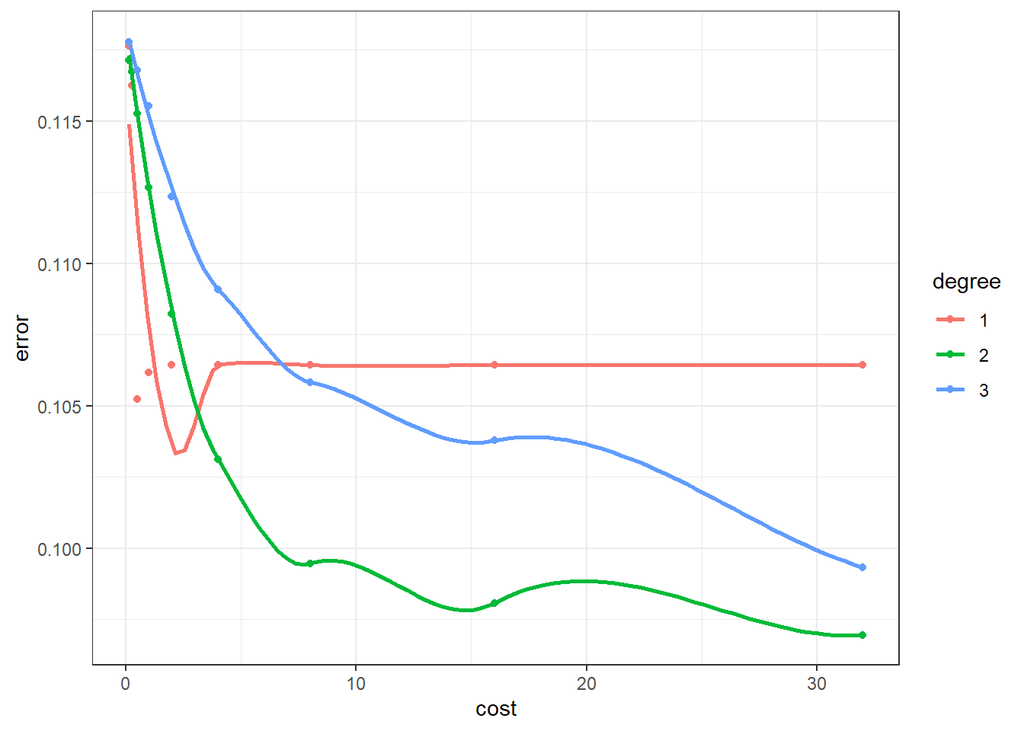

```r
svm.polynomial$performances %>%
    ggplot(aes(x=cost, y=error, color=as.factor(degree))) +
    geom_point() +
    geom_smooth(se=F, span=0.8) +
    labs(color="degree") +
    theme_bw()
```

```r
# Extract the best model
best_svm_model <- svm.polynomial$best.model
```

```r
# Make predictions on the test dataset
test_predictions <- predict(best_svm_model, newdata = test_data)
conf_matrix_test <- confusionMatrix(test_predictions, test_data$y,mode = "everything", positive="1")
conf_matrix_test
```

```
## Confusion Matrix and Statistics
##
##           Reference
## Prediction    0    1
##          0 7830  651
##          1  154  406
##
##                Accuracy : 0.911
##                  95% CI : (0.9049, 0.9168)
##     No Information Rate : 0.8831
##     P-Value [Acc > NIR] : < 2.2e-16
##
##                   Kappa : 0.4583
##
##  Mcnemar's Test P-Value : < 2.2e-16
##
##             Sensitivity : 0.38411
##             Specificity : 0.98071
##          Pos Pred Value : 0.72500
##          Neg Pred Value : 0.92324
##               Precision : 0.72500
##                  Recall : 0.38411
##                      F1 : 0.50216
##              Prevalence : 0.11691
##          Detection Rate : 0.04491
##    Detection Prevalence : 0.06194
##       Balanced Accuracy : 0.68241
##
##        'Positive' Class : 1
##
```

## 5.3 Decision tree

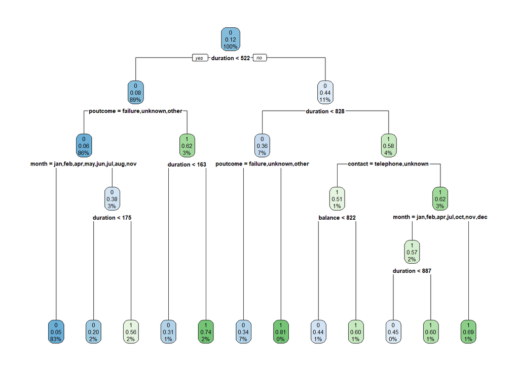

```r
set.seed(208)
model.DT <- rpart(y~., data = bank, method = "class", cp = 0.001, minsplit = 400, maxdepth = 5)
rpart.plot(model.DT)
```

```r
test_predictions <- predict(model.DT, newdata = test_data, type = "class")
conf_matrix_test <- confusionMatrix(test_predictions, test_data$y,mode = "everything",positive="1")
conf_matrix_test
```

```
## Confusion Matrix and Statistics
##
##           Reference
## Prediction    0    1
##          0 7773  656
##          1  211  401
##
##                Accuracy : 0.9041
##                  95% CI : (0.8978, 0.9101)
##     No Information Rate : 0.8831
##     P-Value [Acc > NIR] : 9.267e-11
##
##                   Kappa : 0.4318
##
##  Mcnemar's Test P-Value : < 2.2e-16
##
##             Sensitivity : 0.37938
##             Specificity : 0.97357
##          Pos Pred Value : 0.65523
##          Neg Pred Value : 0.92217
##               Precision : 0.65523
##                  Recall : 0.37938
##                      F1 : 0.48053
##              Prevalence : 0.11691
##          Detection Rate : 0.04435
##    Detection Prevalence : 0.06769
##       Balanced Accuracy : 0.67647
##
##        'Positive' Class : 1
##
```

## 5.4 Random Forests

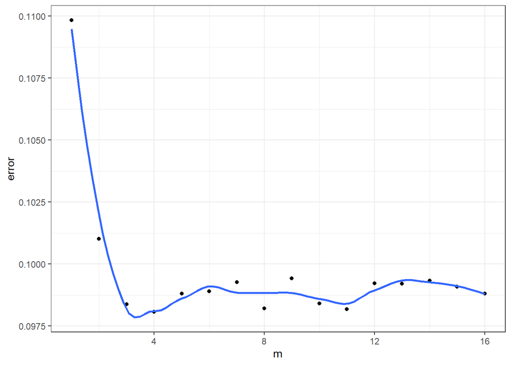

```r
set.seed(208)
results <- double(16)

for(m in 1:16) {
  model.RF <- randomForest(y~., data=bank, mtry=m, ntree=100)
  results[m] <- mean(model.RF$err.rate[,1])
}

tibble(m=1:16, error=results) %>%
  ggplot(aes(x=m, y=error)) +
  geom_point() +
  geom_smooth(se=F,span=0.4) +
  theme_bw()
```

```r
which(results == min(results)) #7
```

```
## [1] 4
```

```r
model.RF <- randomForest(y~., data=train_data, mtry=10, ntree=100)

test_predictions <- predict(model.RF, newdata = test_data, type = "class")
conf_matrix_test <- confusionMatrix(test_predictions, test_data$y,mode = "everything",positive="1")

conf_matrix_test
```

```
## Confusion Matrix and Statistics
##
##           Reference
## Prediction    0    1
##          0 7646  509
##          1  338  548
##
##                Accuracy : 0.9063
##                  95% CI : (0.9001, 0.9122)
##     No Information Rate : 0.8831
##     P-Value [Acc > NIR] : 7.83e-13
##
##                   Kappa : 0.512
##
##  Mcnemar's Test P-Value : 5.18e-09
##
##             Sensitivity : 0.51845
##             Specificity : 0.95767
##          Pos Pred Value : 0.61851
##          Neg Pred Value : 0.93758
##               Precision : 0.61851
##                  Recall : 0.51845
##                      F1 : 0.56408
##              Prevalence : 0.11691
##          Detection Rate : 0.06061
##    Detection Prevalence : 0.09800
##       Balanced Accuracy : 0.73806
##
##        'Positive' Class : 1
##
```

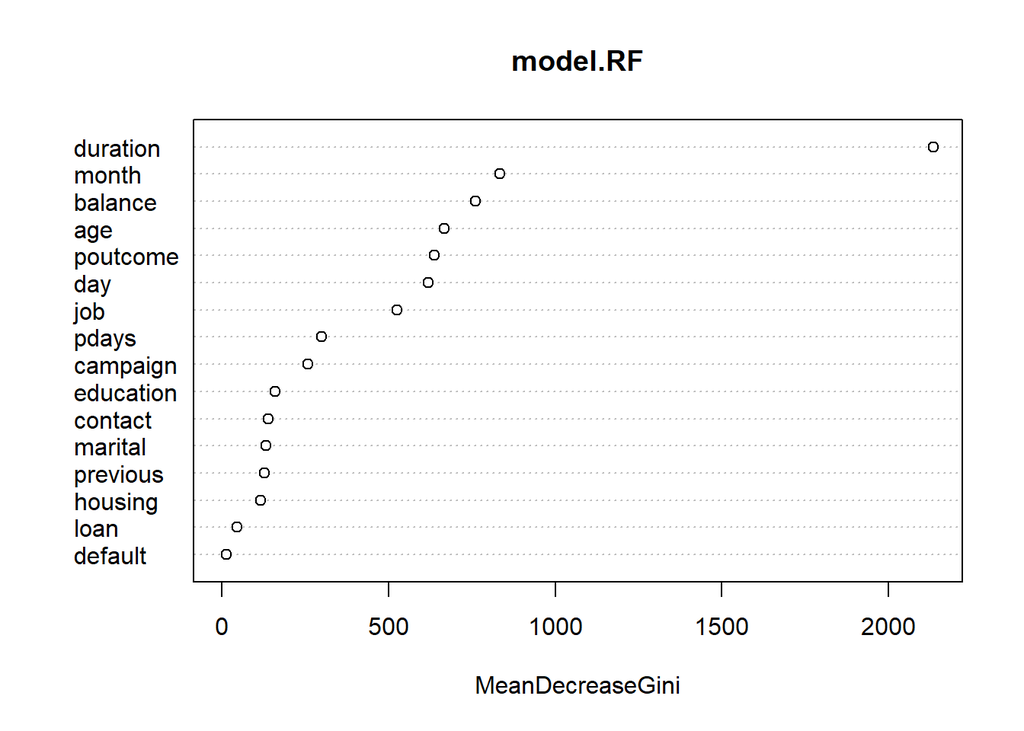

```r
varImpPlot(model.RF)
```

## 5.5 KNN

```r
set.seed(208)
knn_model_cv <- train(y ~ ., data = train_data, method = "knn", trControl = train_control, tuneLength = 10)
print(knn_model_cv)
```

```
## k-Nearest Neighbors
##
## 36170 samples
##    16 predictor
##     2 classes: '0', '1'
##
## No pre-processing
## Resampling: Cross-Validated (10 fold)
## Summary of sample sizes: 32552, 32553, 32554, 32553, 32553, 32553, ...
## Resampling results across tuning parameters:
##
##   k   Accuracy   Kappa
##    5  0.8819186  0.2945344
##    7  0.8837157  0.2864649
##    9  0.8845729  0.2794491
##   11  0.8858998  0.2759073
##   13  0.8862870  0.2759143
##   15  0.8869230  0.2707166
##   17  0.8863423  0.2602685
##   19  0.8867846  0.2582805
##   21  0.8863698  0.2505298
##   23  0.8867569  0.2484841
##
## Accuracy was used to select the optimal model using the largest value.
## The final value used for the model was k = 15.
```

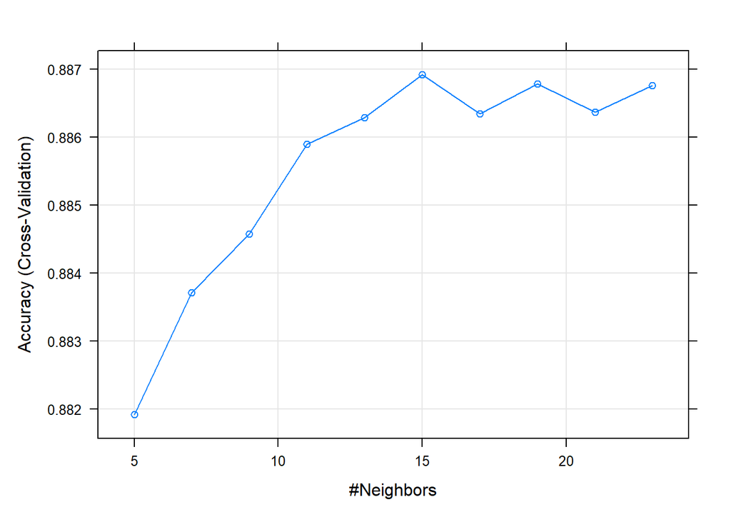

```r
plot(knn_model_cv)
```

**This chart shows the k = 15 with accuracy approximately 88.69% for training dataset.**

```r
prediction <- predict(knn_model_cv, newdata = test_data, mode = "everything", positive = "1")
cf <- confusionMatrix(prediction, test_data$y, mode = "everything", positive = "1")
cf
```

```
## Confusion Matrix and Statistics
##
##           Reference
## Prediction    0    1
##          0 7752  803
##          1  232  254
##
##                Accuracy : 0.8855
##                  95% CI : (0.8788, 0.892)
##     No Information Rate : 0.8831
##     P-Value [Acc > NIR] : 0.2415
##
##                   Kappa : 0.2759
##
##  Mcnemar's Test P-Value : <2e-16
##
##             Sensitivity : 0.24030
##             Specificity : 0.97094
##          Pos Pred Value : 0.52263
##          Neg Pred Value : 0.90614
##               Precision : 0.52263
##                  Recall : 0.24030
##                      F1 : 0.32923
##              Prevalence : 0.11691
##          Detection Rate : 0.02809
##    Detection Prevalence : 0.05376
##       Balanced Accuracy : 0.60562
##
##        'Positive' Class : 1
##
```

**With inital k = 15, the model correctly predict 88.55% target variable in test data set.**